# SQL-NoSQL analysis

Kathleen DeBrota

April 21, 2019

This document is for some analysis and visualizations of the credit card data set for SQL/NoSQL final project.

Guiding questions: What kind of person is most likely to default on their credit card payments? What demographic factor(s) are most important in predicting this?

1. Are younger people more or less likely to default on payments?
2. Are higher-educated people more or less likely to default?
3. How is credit limit associated with likelihood to default? How is credit limit associated with age and education level?
4. At what bill value is someone more likely to default on their payment? Are there any demographic trends that emerge there?
5. Is the amount of one single bill more influential than whether or not the person delayed their last bill in deciding whether someone will default?

```r
library(readxl)
library(dplyr)
library(lattice)
library(rcompanion)
```

```r
library(ggplot2)
library(Rcmdr)
library(gplots)
library(corrplot)
library(factoextra)
library(rgl)
library(purrr)
setwd("C:/Users/kdebr/Documents/GitHub/sql-nosql")
credit<-read.csv(file='cleanData.csv')
head(credit)
```

```
##   ID LIMIT_BAL    SEX      EDUCATION MARRIAGE AGE PAY_1 PAY_2 PAY_3 PAY_4
## 1  1     20000 female under graduate  married  24     2     2    -1    -1
## 2  2    120000 female under graduate   single  26    -1     2     0     0
## 3  3     90000 female under graduate   single  34     0     0     0     0
## 4  4     50000 female under graduate  married  37     0     0     0     0
## 5  5     50000   male under graduate  married  57    -1     0    -1     0
## 6  6     50000   male       graduate   single  37     0     0     0     0
##   PAY_5 PAY_6 BILL_AMT1 BILL_AMT2 BILL_AMT3 BILL_AMT4 BILL_AMT5 BILL_AMT6
## 1    -2    -2      3913      3102       689         0         0         0
## 2     0     2      2682      1725      2682      3272      3455      3261
## 3     0     0     29239     14027     13559     14331     14948     15549
## 4     0     0     46990     48233     49291     28314     28959     29547
## 5     0     0      8617      5670     35835     20940     19146     19131
## 6     0     0     64400     57069     57608     19394     19619     20024
##   PAY_AMT1 PAY_AMT2 PAY_AMT3 PAY_AMT4 PAY_AMT5 PAY_AMT6
## 1        0      689        0        0        0        0
## 2        0     1000     1000     1000        0     2000
## 3     1518     1500     1000     1000     1000     5000
## 4     2000     2019     1200     1100     1069     1000
## 5     2000    36681    10000     9000      689      679
## 6     2500     1815      657     1000     1000      800
##   DEFAULT_PAYMENT_NEXT_MONTH
## 1                          1
## 2                          1
## 3                          0
## 4                          0
## 5                          0
## 6                          0
```

Exploratory views of the data.

```r
summary(credit)
```

```
##        ID          LIMIT_BAL           SEX                 EDUCATION
##  Min.   :    1   Min.   :  10000   female:18112   graduate      :10585
##  1st Qu.: 7501   1st Qu.:  50000   male  :11888   high school   : 4917
##  Median :15000   Median : 140000                  others        :  123
##  Mean   :15000   Mean   : 167484                  under graduate:14030
##  3rd Qu.:22500   3rd Qu.: 240000                  uneducated    :   14
##  Max.   :30000   Max.   :1000000                  unknown       :  331
##     MARRIAGE          AGE            PAY_1             PAY_2
##  married:13659   Min.   :21.00   Min.   :-2.0000   Min.   :-2.0000
##  others :  323   1st Qu.:28.00   1st Qu.:-1.0000   1st Qu.:-1.0000
##  single :15964   Median :34.00   Median : 0.0000   Median : 0.0000
##  unknown:   54   Mean   :35.49   Mean   :-0.0167   Mean   :-0.1338
##                  3rd Qu.:41.00   3rd Qu.: 0.0000   3rd Qu.: 0.0000
##                  Max.   :79.00   Max.   : 8.0000   Max.   : 8.0000
##      PAY_3             PAY_4             PAY_5             PAY_6
##  Min.   :-2.0000   Min.   :-2.0000   Min.   :-2.0000   Min.   :-2.0000
##  1st Qu.:-1.0000   1st Qu.:-1.0000   1st Qu.:-1.0000   1st Qu.:-1.0000
##  Median : 0.0000   Median : 0.0000   Median : 0.0000   Median : 0.0000
##  Mean   :-0.1662   Mean   :-0.2207   Mean   :-0.2662   Mean   :-0.2911
##  3rd Qu.: 0.0000   3rd Qu.: 0.0000   3rd Qu.: 0.0000   3rd Qu.: 0.0000
##  Max.   : 8.0000   Max.   : 8.0000   Max.   : 8.0000   Max.   : 8.0000
##    BILL_AMT1         BILL_AMT2        BILL_AMT3         BILL_AMT4
##  Min.   :-165580   Min.   :-69777   Min.   :-157264   Min.   :-170000
##  1st Qu.:   3559   1st Qu.:  2985   1st Qu.:   2666   1st Qu.:   2327
##  Median :  22382   Median : 21200   Median :  20089   Median :  19052
##  Mean   :  51223   Mean   : 49179   Mean   :  47013   Mean   :  43263
##  3rd Qu.:  67091   3rd Qu.: 64006   3rd Qu.:  60165   3rd Qu.:  54506
##  Max.   : 964511   Max.   :983931   Max.   :1664089   Max.   : 891586
##    BILL_AMT5        BILL_AMT6          PAY_AMT1         PAY_AMT2
##  Min.   :-81334   Min.   :-339603   Min.   :     0   Min.   :      0
##  1st Qu.:  1763   1st Qu.:   1256   1st Qu.:  1000   1st Qu.:    833
##  Median : 18105   Median :  17071   Median :  2100   Median :   2009
##  Mean   : 40311   Mean   :  38872   Mean   :  5664   Mean   :   5921
##  3rd Qu.: 50191   3rd Qu.:  49198   3rd Qu.:  5006   3rd Qu.:   5000
##  Max.   :927171   Max.   : 961664   Max.   :873552   Max.   :1684259
##     PAY_AMT3         PAY_AMT4         PAY_AMT5           PAY_AMT6
##  Min.   :     0   Min.   :     0   Min.   :     0.0   Min.   :     0.0
##  1st Qu.:   390   1st Qu.:   296   1st Qu.:   252.5   1st Qu.:   117.8
##  Median :  1800   Median :  1500   Median :  1500.0   Median :  1500.0
##  Mean   :  5226   Mean   :  4826   Mean   :  4799.4   Mean   :  5215.5
##  3rd Qu.:  4505   3rd Qu.:  4013   3rd Qu.:  4031.5   3rd Qu.:  4000.0
##  Max.   :896040   Max.   :621000   Max.   :426529.0   Max.   :528666.0
##  DEFAULT_PAYMENT_NEXT_MONTH
##  Min.   :0.0000
##  1st Qu.:0.0000
##  Median :0.0000
##  Mean   :0.2212
##  3rd Qu.:0.0000
##  Max.   :1.0000
```

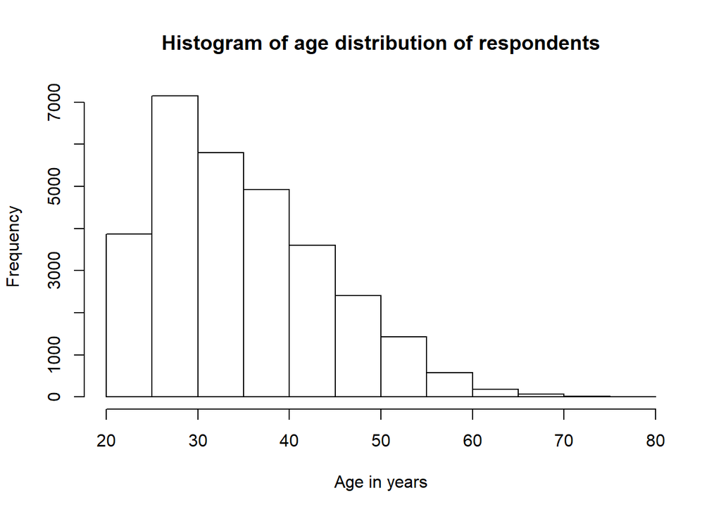

```r
#view thistograms of demographic data
hist(credit$AGE, main='Histogram of age distribution of respondents', ylab='Frequency', xlab='Age in years')
```

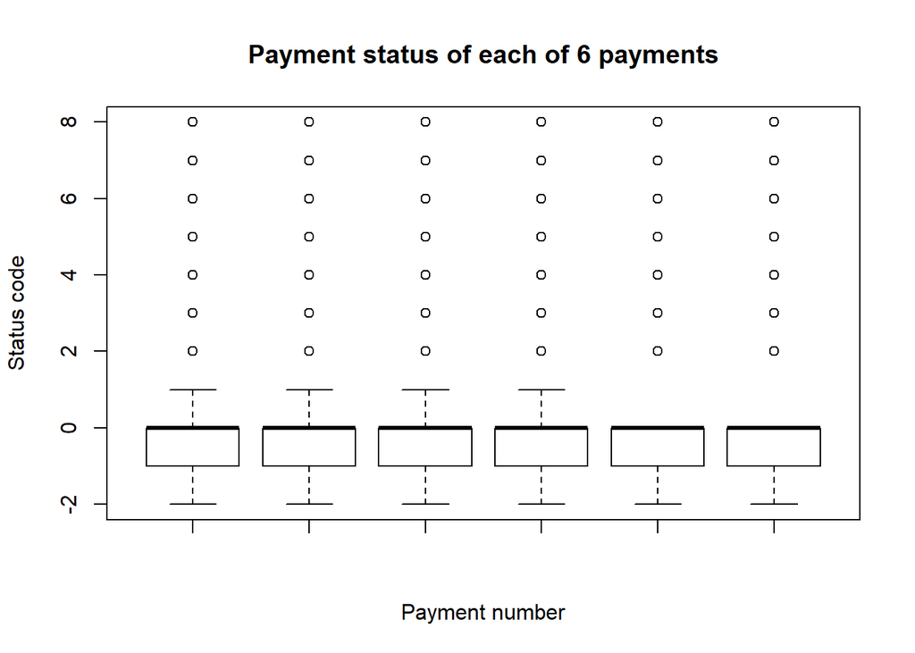

```r
#Boxplot of the payment status for each of the 6 payments.
boxplot(credit$PAY_1, credit$PAY_2, credit$PAY_3, credit$PAY_4, credit$PAY_5, credit$PAY_6, main='Payment status of each of 6 payments', ylab='Status code', xlab='Payment number')
```

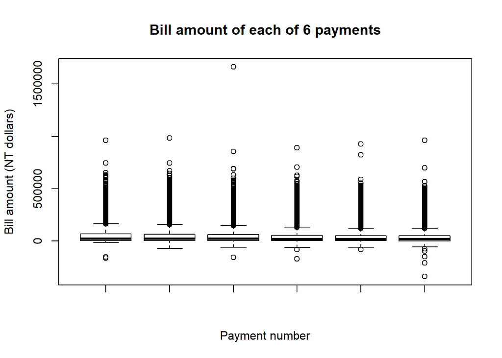

```r
#Boxplot of payment amount for each of 6 payments.
boxplot(credit$BILL_AMT1, credit$BILL_AMT2, credit$BILL_AMT3, credit$BILL_AMT4, credit$BILL_AMT5, credit$BILL_AMT6, main='Bill amount of each of 6 payments', ylab='Bill amount (NT dollars)', xlab='Payment number')
```

Separate out just those who defaulted and who did not. Visualize general demographic differences

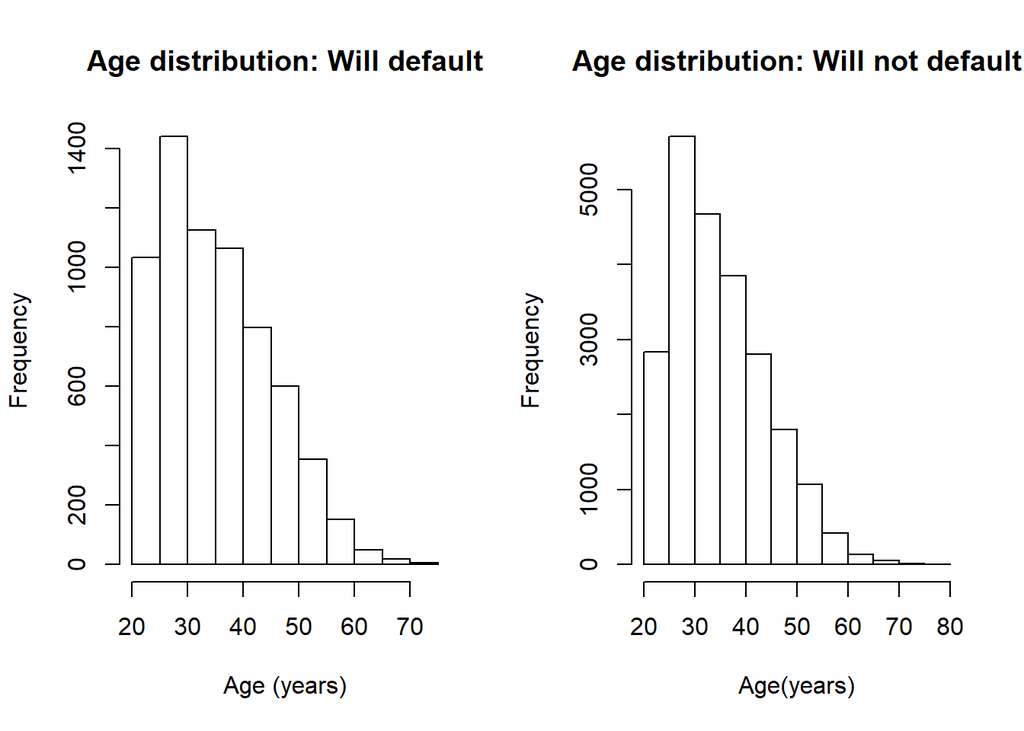

```r
will_default<-subset(credit, DEFAULT_PAYMENT_NEXT_MONTH==1)
z3countdef<-table(will_default$AGE, will_default$MARRIAGE)

will_pay<-subset(credit, DEFAULT_PAYMENT_NEXT_MONTH==0)
#countpay<- table(will_pay$AGE, will_pay$MARRIAGE)

credit$MARRIAGE<-as.factor(credit$MARRIAGE)
credit$DEFAULT_PAYMENT_NEXT_MONTH <-as.factor(credit$DEFAULT_PAYMENT_NEXT_MONTH)

par(mfrow=c(1,2))
#View ages of those who did and did not default.
hist(will_default$AGE, main='Age distribution: Will default', xlab='Age (years)', ylab='Frequency')
hist(will_pay$AGE, main='Age distribution: Will not default', xlab='Age(years)', ylab='Frequency')
```

```r
#----------------------------------------------

#View marital status of those who did/didn't default.
par(mfrow=c(1,1))
marriage <-credit %>% group_by(MARRIAGE, DEFAULT_PAYMENT_NEXT_MONTH) %>% count(DEFAULT_PAYMENT_NEXT_MONTH)
marriage #this shows the counts of people per group.
```

```
## # A tibble: 8 x 3
## # Groups:   MARRIAGE, DEFAULT_PAYMENT_NEXT_MONTH [8]
##   MARRIAGE DEFAULT_PAYMENT_NEXT_MONTH     n
##   <fct>    <fct>                      <int>
## 1 married  0                          10453
## 2 married  1                           3206
## 3 others   0                            239
## 4 others   1                             84
## 5 single   0                          12623
## 6 single   1                           3341
## 7 unknown  0                             49
## 8 unknown  1                              5
```

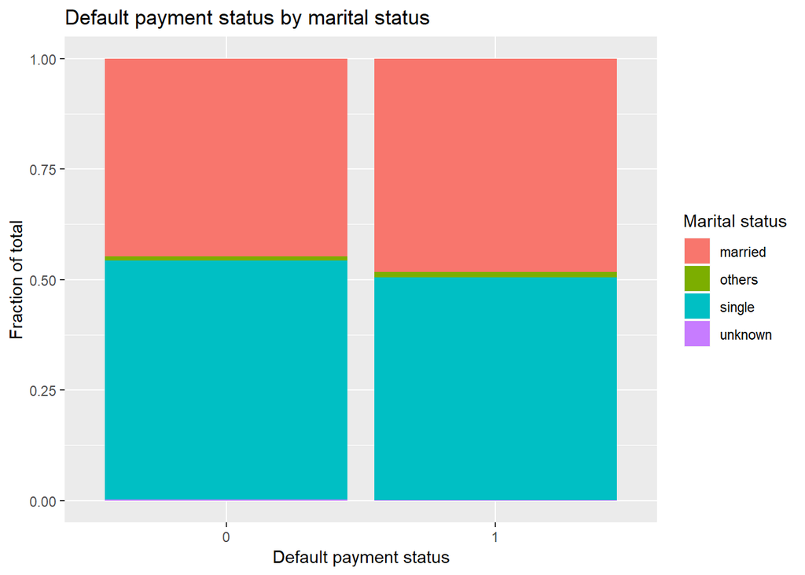

```r
#This is split by payment default status
ggplot(marriage, aes(fill=MARRIAGE, x=DEFAULT_PAYMENT_NEXT_MONTH, y=n))+
  geom_bar(stat='identity', position='fill')+
  ggtitle("Default payment status by marital status")+
  ylab("Fraction of total")+
  xlab('Default payment status')+
  labs(fill='Marital status')
```

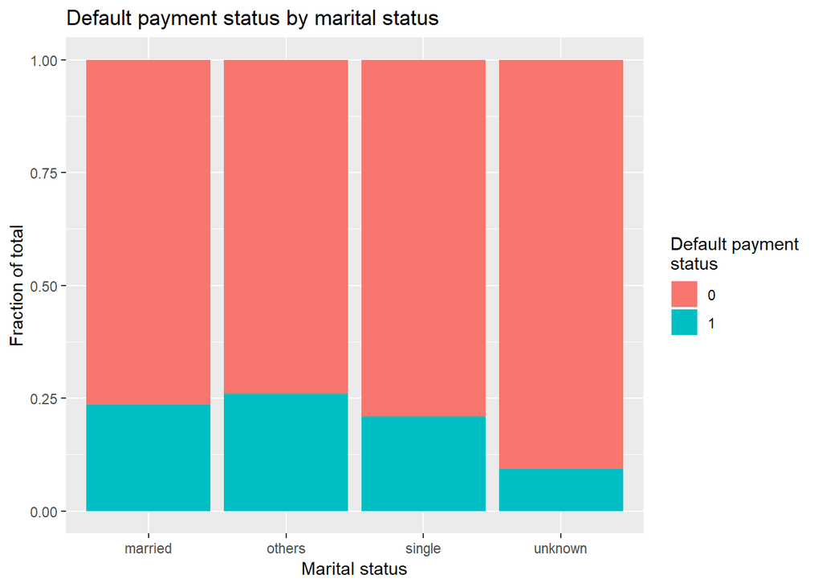

```r
#This is split by marriage status
ggplot(marriage, aes(fill=DEFAULT_PAYMENT_NEXT_MONTH, x=MARRIAGE, y=n))+
  geom_bar(stat='identity', position='fill')+
  ggtitle("Default payment status by marital status")+
  ylab("Fraction of total")+
  xlab('Marital status')+
  labs(fill='Default payment \nstatus')
```

```r
#barchart(marriage$n~marriage$DEFAULT_PAYMENT_NEXT_MONTH, ylab='Number of people', xlab='Payment default status', main='Influence of marital status on default payments', stacked=TRUE, groups=marriage$MARRIAGE, auto.key=list(space='right', title='Marriage status', cex.title=0.8))

#----------------------------------------------

#View education status of those who did/did not default.
education <-credit %>% group_by(EDUCATION, DEFAULT_PAYMENT_NEXT_MONTH) %>% count(DEFAULT_PAYMENT_NEXT_MONTH)
education #this shows the counts of people per group.
```

```
## # A tibble: 11 x 3
## # Groups:   EDUCATION, DEFAULT_PAYMENT_NEXT_MONTH [11]
##    EDUCATION      DEFAULT_PAYMENT_NEXT_MONTH     n
##    <fct>          <fct>                      <int>
##  1 graduate       0                           8549
##  2 graduate       1                           2036
##  3 high school    0                           3680
##  4 high school    1                           1237
##  5 others         0                            116
##  6 others         1                              7
##  7 under graduate 0                          10700
##  8 under graduate 1                           3330
##  9 uneducated     0                             14
## 10 unknown        0                            305
## 11 unknown        1                             26
```

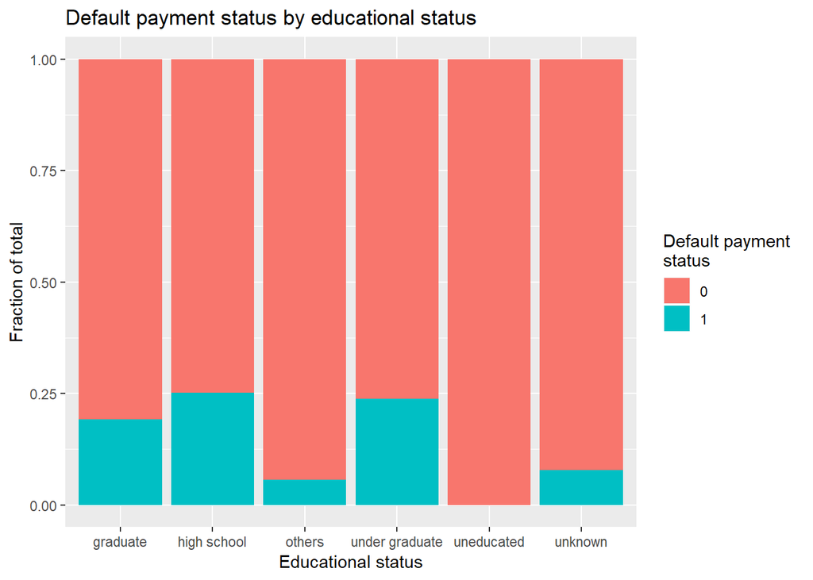

```r
#This is split by education status
ggplot(education, aes(fill=DEFAULT_PAYMENT_NEXT_MONTH, x=EDUCATION, y=n))+
  geom_bar(stat='identity', position='fill')+
  ggtitle("Default payment status by educational status")+
  ylab("Fraction of total")+
  xlab('Educational status')+
  labs(fill='Default payment \nstatus')
```